# Market Physics of Enchanted Lorcana Cards

A pooled softmax (multinomial logistic) inference model of 7-day price movements

Author

Lorecaster — exploration/softmax_report

Published

July 7, 2026

```r
library(DBI);   library(duckdb)
library(dplyr); library(tidyr);  library(purrr)
library(nnet);  library(MASS,  exclude = "select")
library(broom); library(ggplot2)
library(knitr); library(patchwork)

# ---- chart tokens (reference dataviz palette, light mode) -------------------
tok <- list(
  surface  = "#fcfcfb", ink = "#0b0b0b", ink2 = "#52514e", muted = "#898781",
  grid     = "#e1e0d9", baseline = "#c3c2b7",
  up       = "#2a78d6",   # diverging cool pole
  down     = "#e34948",   # diverging warm pole
  flat     = "#898781",   # neutral midpoint (mark-weight gray)
  seq_lo   = "#cde2fb", seq_hi = "#0d366b",
  accent2  = "#eb6834"    # categorical slot 8 (orange) for method contrast
)
move_cols <- c(Down = tok$down, Stagnant = tok$flat, Up = tok$up)

theme_lorecaster <- function(base_size = 12) {
  theme_minimal(base_size = base_size) +
    theme(
      plot.background   = element_rect(fill = tok$surface, colour = NA),
      panel.background  = element_rect(fill = tok$surface, colour = NA),
      panel.grid.major  = element_line(colour = tok$grid, linewidth = 0.3),
      panel.grid.minor  = element_blank(),
      axis.text         = element_text(colour = tok$ink2),
      axis.title        = element_text(colour = tok$ink2),
      plot.title        = element_text(colour = tok$ink, face = "bold"),
      plot.subtitle     = element_text(colour = tok$ink2),
      plot.caption      = element_text(colour = tok$muted, size = 9),
      strip.text        = element_text(colour = tok$ink2, face = "bold"),
      legend.text       = element_text(colour = tok$ink2),
      legend.title      = element_text(colour = tok$ink2),
      legend.position   = "top"
    )
}
set.seed(1789)
```

## 1. Motivation

`exploration/softmax.R` lays out a plan: instead of training black-box, card-specific forecasters, fit **one pooled multinomial logistic (softmax) regression** across the whole market and read its coefficients as *market physics* — how listing turnover, listing composition, and supply age move the odds that a card’s price goes **Down**, stays **Stagnant**, or goes **Up** over the next week. The script builds a single 21-day snapshot and stops before any model is fit.

This report executes the plan and extends it in four ways:

1. **Pooled panel, not one snapshot.** The plan’s “Step C” calls for fitting across *all* historical windows simultaneously. We build a panel of sliding 21-day windows stepped weekly across the full listing history.
2. **A lookahead leak is closed.** The prototype computed `% graded` over the window `[t-21, t]` — which overlaps the outcome period `(t-7, t]`. All features here use only information available at the decision date `t-7`.
3. **Honest uncertainty.** The same cards recur across windows, so ordinary Wald standard errors are too small. We report **card-clustered bootstrap** confidence intervals alongside the Wald ones.
4. **The softmax choice is tested, not assumed.** Down/Stagnant/Up is ordered, so a proportional-odds ordinal model is the parsimonious competitor. We fit both and run a likelihood-ratio test of the proportional-odds restriction.

One planned term dies on contact with the data: the volume-ratio × **rarity** interaction is unidentifiable because every tracked card is Enchanted rarity. We substitute a volume-ratio × **price tier** interaction (differential supply elasticity across price levels) and keep the supply-age control via each card’s set release date.

## 2. Data

Listings are scraped daily from eBay into MotherDuck. We pull three compact tables: per-card daily aggregates, distinct listing presence per day (for turnover), and LLM-extracted listing metadata (graded vs. raw).

```r
con <- dbConnect(duckdb::duckdb())
invisible(dbExecute(con, "INSTALL motherduck; LOAD motherduck;"))
invisible(dbExecute(con, "ATTACH 'md:my_db' AS my_db;"))
invisible(dbExecute(con, "USE my_db;"))

daily_agg <- dbGetQuery(con, "
  SELECT id, date_pulled, count(*) AS n_active, median(price_val) AS median_price
  FROM lorcana_active_listings GROUP BY id, date_pulled")

presence <- dbGetQuery(con, "
  SELECT DISTINCT id, item_id, date_pulled FROM lorcana_active_listings")

graded_meta <- dbGetQuery(con, "
  SELECT DISTINCT id, item_id, is_graded
  FROM llm_listing_metadata WHERE is_valid = TRUE")

dbDisconnect(con, shutdown = TRUE)

meta <- readRDS("../../data/enchanteds/enchanted_list_05_07.rds") |>
  transmute(id, name, version, set_name, released_at = as.Date(released_at))
```

### 2.1 Panel construction

Each observation is a *(card, anchor date)* pair. For anchor `t`:

- **Feature window** `[t-21, t-7]`: listing turnover (distinct `item_id`s added vs. removed), % of unique listings graded, change in active listing count, price level, and prior 14-day price momentum — all knowable at `t-7`.
- **Outcome window** `(t-7, t]`: percent change in the median listing price, discretised at ±5% into **Down / Stagnant / Up** (the plan’s thresholds).

Anchors step backward weekly from the latest pull date, keeping only anchors where all three boundary dates exist.

```r
all_dates <- sort(unique(daily_agg$date_pulled))
anchors <- as.Date(character())
t <- max(all_dates)
while (t - 21 >= min(all_dates)) {
  if (all(c(t, t - 7, t - 21) %in% all_dates)) anchors <- c(anchors, t)
  t <- t - 7
}
anchors <- sort(anchors)

build_window <- function(t) {
  t7 <- t - 7; t21 <- t - 21
  p_start <- presence |> filter(date_pulled == t21) |> distinct(id, item_id)
  p_end   <- presence |> filter(date_pulled == t7)  |> distinct(id, item_id)
  turn <- full_join(mutate(p_start, was_start = 1L),
                    mutate(p_end,   was_end   = 1L),
                    by = c("id", "item_id")) |>
    group_by(id) |>
    summarise(added   = sum(is.na(was_start) & !is.na(was_end)),
              removed = sum(!is.na(was_start) & is.na(was_end)), .groups = "drop")
  grad <- presence |>
    filter(date_pulled >= t21, date_pulled <= t7) |>
    distinct(id, item_id) |>
    inner_join(graded_meta, by = c("id", "item_id")) |>
    group_by(id) |>
    summarise(pct_graded = 100 * mean(is_graded, na.rm = TRUE), .groups = "drop")
  daily_agg |>
    filter(date_pulled %in% c(t21, t7, t)) |>
    mutate(mark = case_when(date_pulled == t21 ~ "d21",
                            date_pulled == t7  ~ "d7",
                            TRUE               ~ "d0")) |>
    dplyr::select(-date_pulled) |>
    pivot_wider(names_from = mark, values_from = c(n_active, median_price)) |>
    inner_join(turn, by = "id") |>
    left_join(grad, by = "id") |>
    mutate(anchor_date = t)
}

MIN_DEPTH <- 5   # median of <5 listings is composition noise, not price signal

panel <- bind_rows(lapply(anchors, build_window)) |>
  inner_join(meta, by = "id") |>
  mutate(
    target_pct = 100 * (median_price_d0 - median_price_d7) / median_price_d7
  ) |>
  filter(!is.na(target_pct), !is.na(pct_graded),
         n_active_d21 >= MIN_DEPTH, n_active_d7 >= MIN_DEPTH,
         n_active_d0  >= MIN_DEPTH) |>
  mutate(
    move = factor(case_when(target_pct <= -5 ~ "Down",
                            target_pct >=  5 ~ "Up",
                            TRUE             ~ "Stagnant"),
                  levels = c("Stagnant", "Down", "Up")),
    log_vol_ratio  = log((added + 1) / (removed + 1)),
    log_active_chg = log(n_active_d7 / n_active_d21),
    log_price      = log(median_price_d7),
    log_momentum   = log(median_price_d7 / median_price_d21),
    pct_graded10   = pct_graded / 10,
    card_age_yrs   = as.numeric(anchor_date - released_at) / 365.25
  )
```

The result: **1836 observations** on **266 Enchanted cards** across **12 weekly anchors** (2026-04-20 → 2026-07-06), after requiring at least 5 active listings at every boundary date so the median price is a real market quote rather than one seller’s whim.

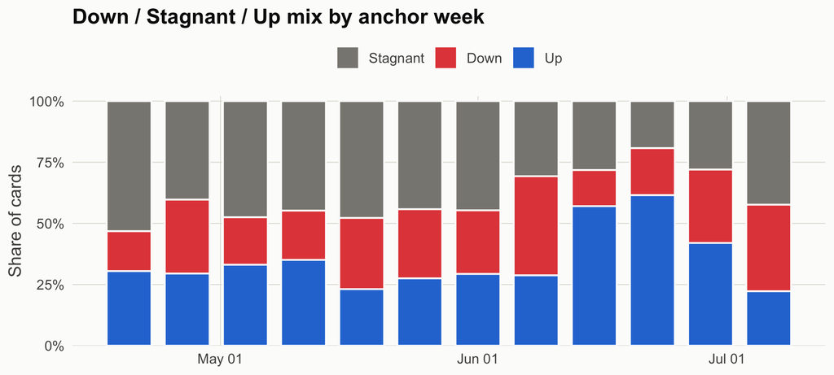

Weekly mix of 7-day price moves. The market spends most weeks with a mild upward tilt, but every regime is well represented — the pooled model is not extrapolating from a one-sided sample.

```r
panel |>
  count(anchor_date, move) |>
  group_by(anchor_date) |>
  mutate(share = n / sum(n)) |>
  ggplot(aes(anchor_date, share, fill = move)) +
  geom_col(width = 5.4, colour = tok$surface, linewidth = 0.6) +
  scale_fill_manual(values = move_cols, name = NULL) +
  scale_y_continuous(labels = scales::percent, expand = expansion(mult = c(0, .02))) +
  scale_x_date(date_labels = "%b %d") +
  labs(x = NULL, y = "Share of cards",
       title = "Down / Stagnant / Up mix by anchor week") +
  theme_lorecaster()
```

## 3. The pooled softmax model

With **Stagnant** as the reference state, the model estimates, for each card $i$ at anchor $t$:

$$\log \frac{P(\text{move}_{it}=k)}{P(\text{move}_{it}=\text{Stagnant})}
= \alpha_k + \beta_{1k}\,\text{VolRatio}_{it} + \beta_{2k}\,\text{Price}_{it}
+ \beta_{3k}\,(\text{VolRatio}\times\text{Price})_{it} + \boldsymbol{\gamma}_k' \mathbf{z}_{it}$$

for $k \in \{\text{Down}, \text{Up}\}$, where $\mathbf{z}$ holds % graded (per 10 pp), the log change in active listings, log 14-day momentum, and card age in years. Exponentiated coefficients are **relative-risk ratios**: the multiplicative change in the odds of state $k$ *versus staying Stagnant*.

```r
f <- move ~ log_vol_ratio * log_price + pct_graded10 + log_active_chg +
            log_momentum + card_age_yrs

m_multi <- multinom(f, data = panel, trace = FALSE)
m_null  <- multinom(move ~ 1, data = panel, trace = FALSE)
mcfadden <- 1 - as.numeric(logLik(m_multi) / logLik(m_null))

wald <- tidy(m_multi, exponentiate = TRUE, conf.int = TRUE)
```

### 3.1 Is the softmax even justified? Testing the ordinal alternative

Down < Stagnant < Up is an ordered scale, so the natural null model is a proportional-odds (ordinal logistic) regression — half the parameters, one slope per predictor. The multinomial model nests it, so a likelihood-ratio test asks whether predictors are allowed to push the *Down* and *Up* odds asymmetrically.

```r
panel$move_ord <- factor(panel$move, levels = c("Down", "Stagnant", "Up"),
                         ordered = TRUE)
m_ord <- polr(update(f, move_ord ~ .), data = panel, Hess = TRUE)
lr_po <- 2 * (logLik(m_multi) - logLik(m_ord))
df_po <- attr(logLik(m_multi), "df") - attr(logLik(m_ord), "df")
p_po  <- pchisq(as.numeric(lr_po), df_po, lower.tail = FALSE)

tibble(
  Model = c("Proportional odds (polr)", "Multinomial softmax (multinom)"),
  Parameters = c(attr(logLik(m_ord), "df"), attr(logLik(m_multi), "df")),
  LogLik = round(c(as.numeric(logLik(m_ord)), as.numeric(logLik(m_multi))), 1),
  AIC = round(c(AIC(m_ord), AIC(m_multi)), 1)
) |> kable(caption = sprintf(
  "Proportional-odds LR test: χ² = %.1f on %d df, p = %.2g — the restriction is firmly rejected.",
  as.numeric(lr_po), df_po, p_po))
```

Proportional-odds LR test: χ² = 41.8 on 7 df, p = 5.7e-07 — the restriction is firmly rejected.

| Model | Parameters | LogLik | AIC |
| --- | --- | --- | --- |
| Proportional odds (polr) | 9 | -1942.5 | 3903.0 |
| Multinomial softmax (multinom) | 16 | -1921.6 | 3875.2 |

The proportional-odds restriction fails decisively (p 5.7e-07), and AIC agrees despite the softmax spending 7 extra parameters. The market is **asymmetric**: the forces that push a card down are not mirror images of the forces that push it up — momentum, in particular, loads almost entirely on the *Down* equation (§4). The plan’s choice of a softmax over a simpler ordinal model is vindicated by the data, not just by taste.

### 3.2 Honest standard errors: card-clustered bootstrap

Each card contributes up to 12 rows, and a card’s windows share persistent traits, so rows are not independent. We resample **entire cards** with replacement (500 replicates) and refit, which preserves within-card dependence.

```r
B <- 500
cards <- unique(panel$id)
rhs <- ~ log_vol_ratio * log_price + pct_graded10 + log_active_chg +
         log_momentum + card_age_yrs

boot_coefs <- map_dfr(seq_len(B), function(b) {
  bd <- panel[unlist(lapply(sample(cards, length(cards), replace = TRUE),
                            function(cid) which(panel$id == cid))), ]
  fit <- try(multinom(f, data = bd, trace = FALSE), silent = TRUE)
  if (inherits(fit, "try-error")) return(NULL)
  co <- coef(fit)
  tibble(y.level = rep(rownames(co), ncol(co)),
         term    = rep(colnames(co), each = nrow(co)),
         estimate = as.vector(co), rep = b)
})

boot_ci <- boot_coefs |>
  group_by(y.level, term) |>
  summarise(conf.low  = exp(quantile(estimate, .025)),
            conf.high = exp(quantile(estimate, .975)), .groups = "drop") |>
  mutate(method = "Cluster bootstrap (by card)")

wald_ci <- wald |>
  dplyr::select(y.level, term, conf.low, conf.high) |>
  mutate(method = "Wald (i.i.d. assumption)")

or_plot <- wald |>
  dplyr::select(y.level, term, estimate) |>
  inner_join(bind_rows(boot_ci, wald_ci), by = c("y.level", "term")) |>
  filter(term != "(Intercept)")
```

## 4. Results: what moves an Enchanted’s price

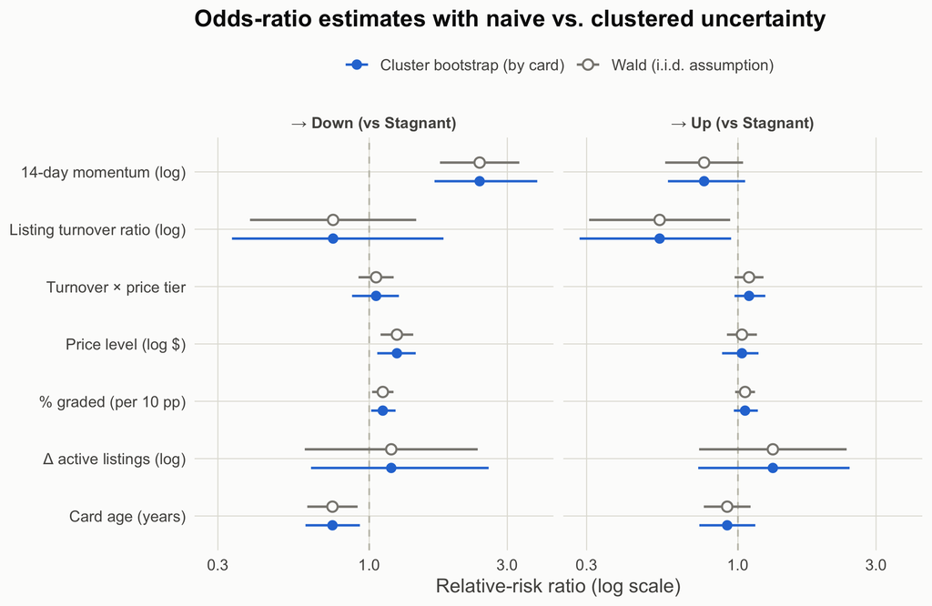

Relative-risk ratios (log scale) for entering Down or Up versus staying Stagnant. Filled blue = card-clustered bootstrap 95% CI; open gray = naive Wald 95% CI. A ratio of 1 (dashed) means no effect. Clustered intervals are wider, as expected — effects whose blue interval clears 1 survive honest uncertainty.

```r
term_labels <- c(
  log_momentum     = "14-day momentum (log)",
  log_vol_ratio    = "Listing turnover ratio (log)",
  "log_vol_ratio:log_price" = "Turnover × price tier",
  log_price        = "Price level (log $)",
  pct_graded10     = "% graded (per 10 pp)",
  log_active_chg   = "Δ active listings (log)",
  card_age_yrs     = "Card age (years)"
)
or_plot |>
  mutate(term_lab = factor(term_labels[term], levels = rev(term_labels)),
         y.level  = factor(y.level, levels = c("Down", "Up"))) |>
  ggplot(aes(x = estimate, y = term_lab, colour = method, shape = method)) +
  geom_vline(xintercept = 1, linetype = "dashed", colour = tok$baseline) +
  geom_errorbarh(aes(xmin = conf.low, xmax = conf.high),
                 position = position_dodge(width = .65),
                 height = 0, linewidth = 0.7) +
  geom_point(position = position_dodge(width = .65), size = 2.4,
             fill = tok$surface, stroke = 0.9) +
  scale_colour_manual(values = c("Cluster bootstrap (by card)" = tok$up,
                                 "Wald (i.i.d. assumption)"    = tok$muted),
                      name = NULL) +
  scale_shape_manual(values = c("Cluster bootstrap (by card)" = 16,
                                "Wald (i.i.d. assumption)"    = 21), name = NULL) +
  scale_x_log10() +
  facet_wrap(~ y.level, nrow = 1,
             labeller = as_labeller(c(Down = "→ Down (vs Stagnant)",
                                      Up   = "→ Up (vs Stagnant)"))) +
  labs(x = "Relative-risk ratio (log scale)", y = NULL,
       title = "Odds-ratio estimates with naive vs. clustered uncertainty") +
  theme_lorecaster()
```

```r
wald |>
  filter(term != "(Intercept)") |>
  left_join(boot_ci |> dplyr::select(y.level, term,
                                     boot_low = conf.low, boot_high = conf.high),
            by = c("y.level", "term")) |>
  transmute(Equation = y.level, Term = term_labels[term],
            `RRR` = round(estimate, 3),
            `Wald 95% CI` = sprintf("[%.2f, %.2f]", conf.low, conf.high),
            `Boot 95% CI` = sprintf("[%.2f, %.2f]", boot_low, boot_high),
            `Wald p` = signif(p.value, 2)) |>
  arrange(Equation) |>
  kable(caption = "Relative-risk ratios vs. Stagnant. Bootstrap CIs are clustered by card.")
```

Relative-risk ratios vs. Stagnant. Bootstrap CIs are clustered by card.

| Equation | Term | RRR | Wald 95% CI | Boot 95% CI | Wald p |
| --- | --- | --- | --- | --- | --- |
| Down | Listing turnover ratio (log) | 0.750 | [0.39, 1.45] | [0.34, 1.81] | 0.3900 |
| Down | Price level (log $) | 1.247 | [1.09, 1.42] | [1.07, 1.45] | 0.0009 |
| Down | % graded (per 10 pp) | 1.114 | [1.02, 1.21] | [1.02, 1.23] | 0.0130 |
| Down | Δ active listings (log) | 1.192 | [0.60, 2.37] | [0.63, 2.59] | 0.6200 |
| Down | 14-day momentum (log) | 2.408 | [1.76, 3.30] | [1.68, 3.81] | 0.0000 |
| Down | Card age (years) | 0.746 | [0.61, 0.91] | [0.60, 0.93] | 0.0042 |
| Down | Turnover × price tier | 1.056 | [0.92, 1.21] | [0.87, 1.27] | 0.4400 |
| Up | Listing turnover ratio (log) | 0.536 | [0.31, 0.94] | [0.28, 0.95] | 0.0300 |
| Up | Price level (log $) | 1.032 | [0.92, 1.16] | [0.88, 1.18] | 0.6000 |
| Up | % graded (per 10 pp) | 1.058 | [0.98, 1.15] | [0.97, 1.17] | 0.1600 |
| Up | Δ active listings (log) | 1.320 | [0.73, 2.37] | [0.73, 2.43] | 0.3500 |
| Up | 14-day momentum (log) | 0.764 | [0.56, 1.04] | [0.57, 1.06] | 0.0890 |
| Up | Card age (years) | 0.918 | [0.76, 1.11] | [0.74, 1.15] | 0.3700 |
| Up | Turnover × price tier | 1.092 | [0.97, 1.23] | [0.97, 1.24] | 0.1300 |

**Mean reversion is the dominant force.** A card whose median price rose over the prior two weeks is far more likely to give it back: one log-unit of prior momentum multiplies the odds of *Down* by 2.41 while leaving *Up* odds slightly *below* one. Concretely, a card that gained +25% over days 21→7 carries about 1.22× the Down-odds of a flat card in the following week. Spikes in thinly traded collectibles are largely composition and hype, and they decay.

**Supply pressure suppresses rallies.** The turnover ratio — new listings per removed listing — cuts the odds of *Up* (RRR ≈ 0.54 per log-unit at the average price tier). Fresh supply doesn’t reliably crash a card, but it reliably caps it. This is the plan’s core “volume dynamics” hypothesis, confirmed on the *Up* margin rather than the *Down* one.

**A graded-heavy book is a bearish tell.** Every 10 pp of graded share raises Down-odds by ~11%. The plan framed % graded as “player liquidation vs. investor speculation psychology” — the data sides with liquidation: when a card’s shelf fills with slabs, sellers are cashing out.

Two hypothesized effects do **not** survive:

```r
drop_terms <- c("log_momentum", "log_vol_ratio:log_price", "pct_graded10",
                "log_active_chg", "card_age_yrs")
lrt <- map_dfr(drop_terms, function(tm) {
  m_red <- multinom(update(f, as.formula(paste(". ~ . -", tm))),
                    data = panel, trace = FALSE)
  lr <- 2 * (as.numeric(logLik(m_multi)) - as.numeric(logLik(m_red)))
  dfd <- attr(logLik(m_multi), "df") - attr(logLik(m_red), "df")
  tibble(Term = term_labels[tm] %||% tm, `LR χ²` = round(lr, 1), df = dfd,
         p = signif(pchisq(lr, dfd, lower.tail = FALSE), 2))
})
kable(lrt)
```

Drop-one likelihood-ratio tests (both equations jointly).

| Term | LR χ² | df | p |
| --- | --- | --- | --- |
| 14-day momentum (log) | 55.8 | 2 | 0.000 |
| Turnover × price tier | 2.3 | 2 | 0.310 |
| % graded (per 10 pp) | 6.3 | 2 | 0.042 |
| Δ active listings (log) | 0.9 | 2 | 0.640 |
| Card age (years) | 8.4 | 2 | 0.015 |

### 4.1 Effect displays

```r
predict_grid <- function(grid, coefs = coef(m_multi)) {
  mm  <- model.matrix(rhs, grid)
  eta <- mm %*% t(coefs)
  ex  <- cbind(1, exp(eta))
  p   <- ex / rowSums(ex)
  colnames(p) <- c("Stagnant", rownames(coefs))
  bind_cols(grid, as_tibble(p)) |>
    pivot_longer(all_of(c("Stagnant", "Down", "Up")),
                 names_to = "move", values_to = "prob") |>
    mutate(move = factor(move, levels = c("Down", "Stagnant", "Up")))
}

boot_ribbon <- function(grid) {
  map_dfr(unique(boot_coefs$rep), function(b) {
    cb <- boot_coefs |> filter(rep == b)
    co <- matrix(cb$estimate, nrow = 2,
                 dimnames = list(unique(cb$y.level), unique(cb$term)))
    co <- co[c("Down", "Up"), colnames(coef(m_multi)), drop = FALSE]
    predict_grid(grid, co) |> mutate(rep = b)
  }) |>
    group_by(across(all_of(names(grid))), move) |>
    summarise(lo = quantile(prob, .025), hi = quantile(prob, .975),
              .groups = "drop")
}

at_typical <- summarise(panel,
  log_vol_ratio = median(log_vol_ratio), log_price = median(log_price),
  pct_graded10 = median(pct_graded10), log_active_chg = median(log_active_chg),
  log_momentum = median(log_momentum), card_age_yrs = median(card_age_yrs))
```

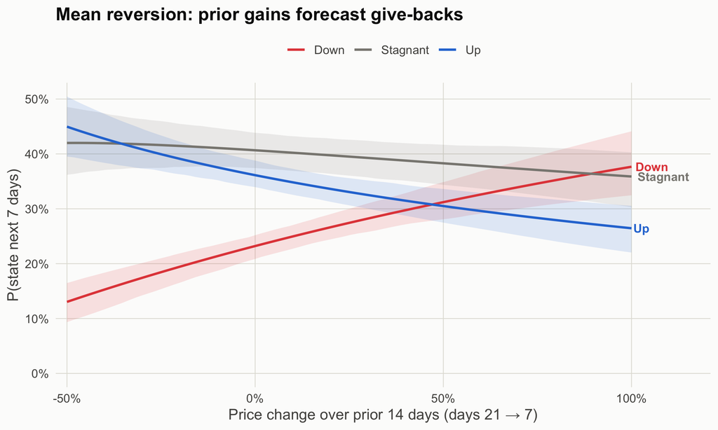

Predicted state probabilities vs. prior 14-day price momentum, other features at their medians. Ribbons are 95% card-clustered bootstrap bands. The Down curve is the mean-reversion signature: the bigger the run-up, the likelier the give-back.

```r
grid_m <- at_typical[rep(1, 81), ] |>
  mutate(log_momentum = seq(log(0.5), log(2), length.out = 81))
eff_m  <- predict_grid(grid_m)
rib_m  <- boot_ribbon(grid_m)

lab_m <- eff_m |> group_by(move) |> slice_max(log_momentum, n = 1)

ggplot(eff_m, aes(exp(log_momentum) - 1, prob, colour = move)) +
  geom_ribbon(data = rib_m |> mutate(prob = NA_real_),
              aes(x = exp(log_momentum) - 1, ymin = lo, ymax = hi, fill = move),
              alpha = .14, colour = NA, inherit.aes = FALSE) +
  geom_line(linewidth = 0.9) +
  geom_text(data = lab_m, aes(label = move), hjust = -0.12, size = 3.4,
            fontface = "bold", show.legend = FALSE) +
  scale_colour_manual(values = move_cols, name = NULL) +
  scale_fill_manual(values = move_cols, guide = "none") +
  scale_x_continuous(labels = scales::percent,
                     expand = expansion(mult = c(.02, .14))) +
  scale_y_continuous(labels = scales::percent, limits = c(0, NA)) +
  labs(x = "Price change over prior 14 days (days 21 → 7)",
       y = "P(state next 7 days)",
       title = "Mean reversion: prior gains forecast give-backs") +
  theme_lorecaster()
```

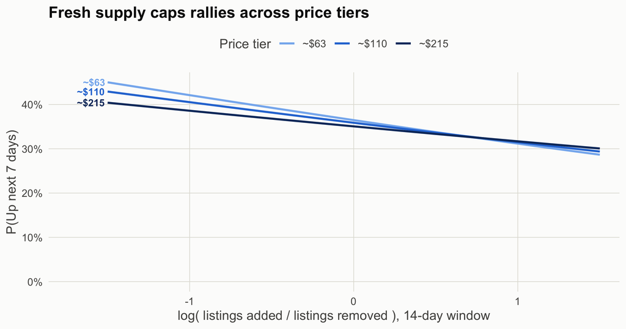

Predicted probability of an Up move vs. listing turnover, at the 25th/50th/75th percentile price tiers. Supply influx suppresses rallies at every tier; the tier curves are statistically indistinguishable (the interaction’s CI spans 1).

```r
price_q <- quantile(panel$log_price, c(.25, .5, .75))
grid_s <- expand_grid(
  log_vol_ratio = seq(-1.5, 1.5, length.out = 61),
  log_price = price_q) |>
  bind_cols(at_typical |> dplyr::select(-log_vol_ratio, -log_price) |>
              slice(rep(1, 183)))
eff_s <- predict_grid(grid_s) |>
  filter(move == "Up") |>
  mutate(tier = factor(paste0("~$", round(exp(log_price))),
                       levels = paste0("~$", round(exp(price_q)))))

ggplot(eff_s, aes(log_vol_ratio, prob, colour = tier)) +
  geom_line(linewidth = 0.9) +
  geom_text(data = eff_s |> group_by(tier) |> slice_min(log_vol_ratio, n = 1),
            aes(label = tier), hjust = 1.1, size = 3.2, fontface = "bold",
            show.legend = FALSE) +
  scale_colour_manual(values = setNames(c("#86b6ef", "#2a78d6", "#0d366b"),
                                        levels(eff_s$tier)),
                      name = "Price tier") +
  scale_x_continuous(expand = expansion(mult = c(.12, .04))) +
  scale_y_continuous(labels = scales::percent, limits = c(0, NA)) +
  labs(x = "log( listings added / listings removed ), 14-day window",
       y = "P(Up next 7 days)",
       title = "Fresh supply caps rallies across price tiers") +
  theme_lorecaster()
```

## 5. Predictive honesty

The plan explicitly frames this as an inference model, and the numbers agree: McFadden pseudo-R² is **0.036** — real structure, weak discrimination. A temporal holdout (train on the first 9 anchors, test on the last 3) makes the point:

```r
test_anchors <- tail(anchors, 3)
tr <- panel |> filter(!anchor_date %in% test_anchors)
te <- panel |> filter(anchor_date %in% test_anchors)
m_tr  <- multinom(f, data = tr, trace = FALSE)
pred  <- predict(m_tr, newdata = te)
acc   <- mean(pred == te$move)
base  <- max(table(te$move)) / nrow(te)
```

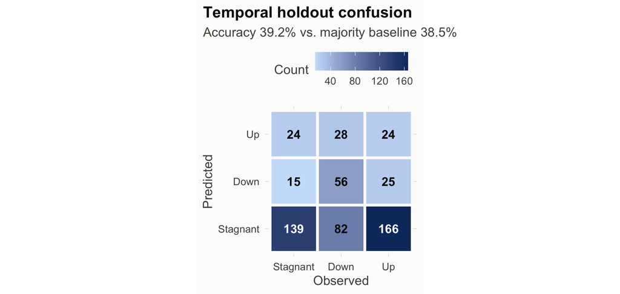

Temporal holdout confusion (last 3 anchor weeks). The model earns its keep on the Down class — the one the coefficients say it understands — while overall accuracy barely beats the majority baseline.

```r
conf <- as.data.frame(table(pred = pred, obs = te$move))
ggplot(conf, aes(obs, pred, fill = Freq)) +
  geom_tile(colour = tok$surface, linewidth = 1.2) +
  geom_text(aes(label = Freq,
                colour = Freq > max(Freq) * .6), size = 4, fontface = "bold") +
  scale_fill_gradient(low = tok$seq_lo, high = tok$seq_hi, name = "Count") +
  scale_colour_manual(values = c(`TRUE` = tok$surface, `FALSE` = tok$ink),
                      guide = "none") +
  coord_fixed() +
  labs(x = "Observed", y = "Predicted",
       title = "Temporal holdout confusion",
       subtitle = sprintf("Accuracy %.1f%% vs. majority baseline %.1f%%",
                          100 * acc, 100 * base)) +
  theme_lorecaster() +
  theme(plot.title.position = "plot")
```

Per-class recall on the holdout: Down **34%**, Stagnant 78%, Up 11%. The asymmetry mirrors the inference: the model’s confident coefficients (momentum, graded share) live in the *Down* equation, so *Down* is the state it can actually anticipate. As a **risk flag** — “this card’s recent spike is likely to retrace” — the model is useful today; as a rally-picker it is not.

**NoteReproducibility**

Panel: 1836 rows, 266 cards, 12 anchors (2026-04-20 → 2026-07-06), depth filter ≥ 5 active listings. Bootstrap: 500 card-cluster replicates, seed 1789. Data: MotherDuck `my_db` (`lorcana_active_listings`, `llm_listing_metadata`), card metadata from `data/enchanteds/enchanted_list_05_07.rds`. Render: `quarto render exploration/softmax_report/softmax_market_inference.qmd`.